# Intervalos de confiança, testes de hipótese, regressão linear

Lista avaliativa final – Probabilidade e Estatística

Autor

Fernando Náufel

Data de Publicação

11/12/2023 13:26

# Mentindo a idade

Uma pesquisa perguntou a $799$ adolescentes se eles mentiam a idade para entrar em sites da internet. Das respostas, $49\%$ foram que sim.

1. Qual o erro-padrão de $\hat p$?

   **Resposta**

   Do [livro eletrônico](https://fnaufel.github.io/probestr/ic.html#intervalos-de-confian%C3%A7a-para-a-propor%C3%A7%C3%A3o),

   $$EP = \sqrt{\frac{\hat p(1-\hat p)}{n}}$$

   onde $\hat p = 0{,}49$ e $n = 799$:

   ```r
   n = 799
   p_chapeu <- 0.49

   ep <- sqrt(p_chapeu * (1 - p_chapeu) / n)
   ep
   ```

   ```
   [1] 0,01768519
   ```

2. O que significa este erro-padrão?

   **Resposta**

   Existem muitas amostras possíveis de $799$ pessoas da população.

   Cada amostra dá um valor de $\hat p$.

   Escolher uma amostra é um experimento probabilístico; então, $\hat p$ é uma variável aleatória, cujo valor depende da amostra tomada.

   Toda variável aleatória tem uma distribuição.

   A distribuição de $\hat p$ é chamada de distribuição amostral de $\hat p$:

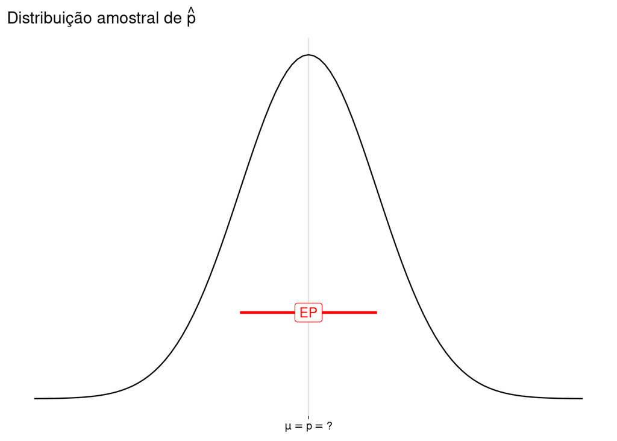

   A distribuição amostral de $\hat p$ é normal.

   A média da distribuição amostral de $\hat p$ é $p$, o valor (desconhecido) da proporção populacional.

   O desvio-padrão da distribuição amostral de $\hat p$ é chamado de erro-padrão (EP), cujo valor foi calculado no item anterior.
3. Construa intervalos de confiança para $p$ com $90\%$, $95\%$ e $99\%$ de confiança.

   **Resposta**

   Usando o pacote `binom` do R:[^1]

   ```r
   library(binom)

   sucessos <- n * p_chapeu
   niveis = c(.9, .95, .99)

   intervalos <- niveis %>%
     map(
       ~binom.confint(sucessos, n, conf.level = .x, methods = 'asymptotic')
     ) %>%
     bind_rows() %>%
     mutate(confiança = niveis) %>%
     select(
       confiança,
       inf = lower,
       sup = upper
     )

   intervalos
   ```

   | confiança | inf | sup |
   | --- | --- | --- |
   | 0,90 | 0,4609105 | 0,5190895 |
   | 0,95 | 0,4553377 | 0,5246623 |
   | 0,99 | 0,4444460 | 0,5355540 |

   Fazendo todos os cálculos:

   ```r
   valores_criticos <- c(
     '90' = -qnorm(.05),
     '95' = -qnorm(.025),
     '99' = -qnorm(.005)
   )

   valores_criticos
   ```

   ```
         90       95       99
   1,644854 1,959964 2,575829
   ```

   ```r
   margens <- valores_criticos * ep
   margens
   ```

   ```
           90         95         99
   0,02908955 0,03466234 0,04555403
   ```

   ```r
   intervalos <- list(
     inf = p_chapeu - margens,
     sup = p_chapeu + margens
   ) %>%
     as_tibble() %>%
     mutate(confiança = niveis, .before = inf)
   intervalos
   ```

   | confiança | inf | sup |
   | --- | --- | --- |
   | 0,90 | 0,4609105 | 0,5190895 |
   | 0,95 | 0,4553377 | 0,5246623 |
   | 0,99 | 0,4444460 | 0,5355540 |

4. Qual dos $3$ intervalos de confiança do item anterior tem a maior margem de erro? Por quê?

   **Resposta**

   O de nível de confiança de $99\%$.

   Para que nosso intervalo tenha apenas $1\%$ de probabilidade de não conter o valor verdadeiro de $p$ (a proporção populacional), a largura do intervalo precisa ser maior.

   Veja uma [explicação detalhada no livro eletrônico](https://fnaufel.github.io/probestr/ic.html#o-que-quer-dizer-95-de-confian%C3%A7a).
5. Faça um teste de hipóteses para verificar se $p$ é diferente de $0{,}5$ com $\alpha = 0{,}1$; $\alpha = 0{,}05$; e $\alpha = 0{,}01$.

   **Resposta**

   Hipóteses:

   Usando o R, vemos que a função `prop.test` só usa o nível de confiança para construir o IC.

   Nos três testes abaixo, só o IC muda.

   Como era de se esperar, o valor p é o mesmo, independente do valor de $\alpha$.

   ```r
   testes <- niveis %>%
    map(
      ~prop.test(
        sucessos,
        n,
        p = .5,
        alternative = 'greater',
        conf.level = .x,
        correct = FALSE
      )
    )
   testes
   ```

   ```
   [[1]]

    1-sample proportions test without continuity correction

   data:  sucessos out of n, null probability 0.5
   X-squared = 0,3196, df = 1, p-value = 0,7141
   alternative hypothesis: true p is greater than 0,5
   90 percent confidence interval:
    0,4673793 1,0000000
   sample estimates:
      p
   0,49


   [[2]]

    1-sample proportions test without continuity correction

   data:  sucessos out of n, null probability 0.5
   X-squared = 0,3196, df = 1, p-value = 0,7141
   alternative hypothesis: true p is greater than 0,5
   95 percent confidence interval:
    0,4609933 1,0000000
   sample estimates:
      p
   0,49


   [[3]]

    1-sample proportions test without continuity correction

   data:  sucessos out of n, null probability 0.5
   X-squared = 0,3196, df = 1, p-value = 0,7141
   alternative hypothesis: true p is greater than 0,5
   99 percent confidence interval:
    0,4490639 1,0000000
   sample estimates:
      p
   0,49
   ```

   O valor de $\alpha$ só é usado depois que descobrimos o valor p.

   Se o valor p for menor que $\alpha$, rejeitamos a hipótese de nulidade; senão, não:

   ```r
   alfa <- function(conf) { 1 - conf }

   testes %>%
     walk2(
       niveis,
       ~cat(
         'α = ', alfa(.y), '\t: ',
         ifelse(
           .x$p.value < alfa(.y),
           '',
           'não'
         ),
         'rejeitar H0.\n'
       )
     )
   ```

   ```
   α =  0,1     :  não rejeitar H0.
   α =  0,05    :  não rejeitar H0.
   α =  0,01    :  não rejeitar H0.
   ```

   Veja, nos resultados dos testes, que o valor p foi $0{,}71$, maior do que os três valores de $\alpha$.

   Logo, nenhum dos três testes rejeitou a hipótese de nulidade (de que a proporção populacional é $0{,}5$).

# Casamento

Em $1960$, a idade média dos homens no momento do primeiro casamento era de $23{,}3$ anos.

Em uma amostra de $40$ homens que se casaram pela primeira vez no ano passado, as idades eram:

```r
idades <- c(
  24.4, 27.6, 34.0, 20.8, 23.7, 34.3, 14.3, 23.9, 23.6, 21.5, 26.4,
  10.6, 27.9, 19.3, 17.9, 21.9, 20.3, 25.8, 28.3, 22.5, 33.1, 21.5,
  23.0, 24.0, 20.5, 28.5, 24.0, 25.0, 28.5, 19.8, 22.5, 29.2, 21.2,
  19.2, 22.7, 27.4, 33, 25, 26.4, 23.1
)
```

Os homens estão se casando mais velhos?

Responda com $\alpha = 0{,}1$; com $\alpha = 0{,}05$; e com $\alpha = 0{,}01$?

**Resposta**

Vamos fazer um teste de hipóteses:

$$\begin{aligned}
H_0 : \mu = 23{,}3 \\
H_A : \mu > 23{,}3
\end{aligned}$$

$n = 40$ é um tamanho razoável de amostra. Com este tamanho, não precisamos nos preocupar com a normalidade dos dados, mas um histograma e um teste de Shapiro mostram que eles são aproximadamente normais:

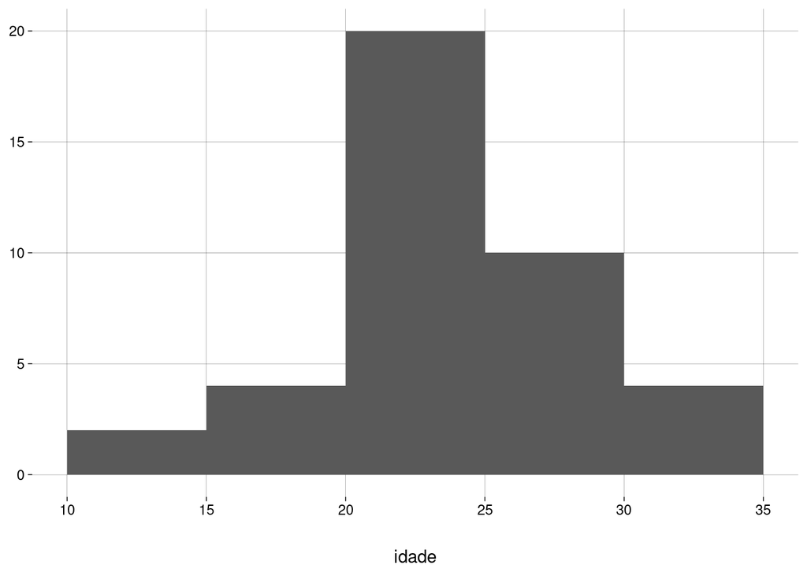

```r
b <- seq(10, 35, 5)

idades %>%
  enframe(name = NULL, value = 'idade') %>%
  ggplot(aes(idade)) +
    geom_histogram(breaks = b) +
    labs(y = NULL)
```

```r
shapiro.test(idades)
```

```
    Shapiro-Wilk normality test

data:  idades
W = 0,96884, p-value = 0,3305
```

Vamos supor que as outras condições do TCL são satisfeitas.

Como não sabemos o desvio-padrão populacional $\sigma$, vamos fazer um teste $t$:

```r
teste <- t.test(
  idades,
  alternative = 'greater',
  mu = 23.3
)

teste
```

```
    One Sample t-test

data:  idades
t = 1,1059, df = 39, p-value = 0,1378
alternative hypothesis: true mean is greater than 23,3
95 percent confidence interval:
 22,8472     Inf
sample estimates:
mean of x
   24,165
```

Como vimos antes, o valor de $\alpha$ não afeta o valor p.

O valor p foi $0{,}14$, que é maior do que os três valores de $\alpha$.

# Pulsação

Um pesquisador examinou as pulsações de homens e mulheres (em bpm):

```r
homens <- c(
  78, 72, 74, 70, 77, 75, 76, 71, 73, 75, 73, 70, 70, 79,
  76, 73, 70, 77, 75, 77, 70, 76, 76, 73, 73, 75, 78, 70
)

mulheres <- c(
  78, 72, 75, 67, 75, 73, 76, 73, 67, 77, 72, 72, 68, 73,
  68, 83, 76, 74, 70, 72, 67, 67, 73, 75, 76, 77, 70, 71
)
```

1. Construa *boxplots* para os dados (separados por sexo).

   **Resposta**

   ```r
   df <- tibble(
     sexo = rep(c('M', 'F'), c(length(homens), length(mulheres))),
     bpm  = c(homens, mulheres)
   )

   df
   ```

   | sexo | bpm |
   | --- | --- |
   | M | 78 |
   | M | 72 |
   | M | 74 |
   | M | 70 |
   | M | 77 |
   | M | 75 |
   | M | 76 |
   | M | 71 |
   | M | 73 |
   | M | 75 |

   [output cut: 46 more lines]

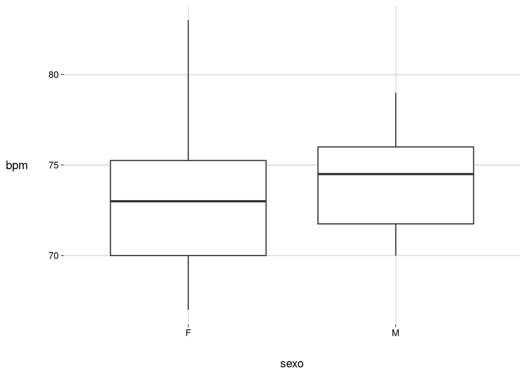

   ```r
   df %>%
     ggplot(aes(sexo, bpm)) +
       geom_boxplot()
   ```

2. O que você nota de estranho?

   **Resposta**

   O espalhamento dos homens é menor do que o das mulheres.
3. Calcule as médias e os desvios-padrão dos grupos.

   **Resposta**

   ```r
   df %>%
     group_by(sexo) %>%
     summarize(
       media = mean(bpm),
       dp = sd(bpm)
     )
   ```

   | sexo | media | dp |
   | --- | --- | --- |
   | F | 72,75 | 3,921687 |
   | M | 74,00 | 2,841492 |

   O desvio-padrão dos homens é uma unidade menor que o das mulheres.
4. Construa intervalos de confiança para a diferença entre as pulsações médias dos homens e das mulheres, considerando que as variâncias dos grupos são diferentes, com $90\%$, $95\%$ e $99\%$ de confiança.

   **Resposta**

   ```r
   niveis = c(.9, .95, .99)

   intervalos_var_dif <- niveis %>%
     map(
       ~ t.test(
         homens,
         mulheres,
         conf.level = .x
       ) %>% tidy()
     ) %>%
     bind_rows() %>%
     mutate(confiança = niveis) %>%
     select(
       confiança,
       inf = conf.low,
       sup = conf.high
     )

   intervalos_var_dif
   ```

   | confiança | inf | sup |
   | --- | --- | --- |
   | 0,90 | -0,2842826 | 2,784283 |
   | 0,95 | -0,5889968 | 3,088997 |
   | 0,99 | -1,2023026 | 3,702303 |

5. Refaça o item acima, considerando que as variâncias dos grupos são iguais. Houve muita mudança?

   **Resposta**

   ```r
   niveis = c(.9, .95, .99)

   intervalos_var_igual <- niveis %>%
     map(
       ~ t.test(
         homens,
         mulheres,
         conf.level = .x,
         var.equal = TRUE
       ) %>% tidy()
     ) %>%
     bind_rows() %>%
     mutate(confiança = niveis) %>%
     select(
       confiança,
       inf = conf.low,
       sup = conf.high
     )

   intervalos_var_igual
   ```

   | confiança | inf | sup |
   | --- | --- | --- |
   | 0,90 | -0,2816843 | 2,781684 |
   | 0,95 | -0,5849107 | 3,084911 |
   | 0,99 | -1,1936302 | 3,693630 |

   Parece que as mudanças foram pequenas.

   Os centros dos intervalos não mudaram:

   ```r
   tibble(
     confiança = niveis,
     centro_var_dif =
       (intervalos_var_dif$inf + intervalos_var_dif$sup) / 2,
     centro_var_igual =
       (intervalos_var_igual$inf + intervalos_var_igual$sup) / 2
   )
   ```

   | confiança | centro_var_dif | centro_var_igual |
   | --- | --- | --- |
   | 0,90 | 1,25 | 1,25 |
   | 0,95 | 1,25 | 1,25 |
   | 0,99 | 1,25 | 1,25 |

   Quanto às larguras dos intervalos:

   ```r
   tibble(
     confiança = niveis,
     largura_var_dif =
       intervalos_var_dif$sup - intervalos_var_dif$inf,
     largura_var_igual =
       intervalos_var_igual$sup - intervalos_var_igual$inf,
     redução_relativa = ((largura_var_dif - largura_var_igual) / largura_var_dif) %>%
       round(3)
   )
   ```

   | confiança | largura_var_dif | largura_var_igual | redução_relativa |
   | --- | --- | --- | --- |
   | 0,90 | 3,068565 | 3,063369 | 0,002 |
   | 0,95 | 3,677994 | 3,669821 | 0,002 |
   | 0,99 | 4,904605 | 4,887260 | 0,004 |

   Considerar as variâncias iguais diminuiu a largura dos intervalos em menos de $0{,}5\%$.

# Sexta-feira 13

Sextas-feiras $13$ são mais perigosas?

Em uma cidade, pesquisadores contaram as quantidades de pacientes admitidos nas emergências de hospitais por causa de acidentes de trânsito.

As contagens foram feitas em diversas sextas-feiras $13$ e nas respectivas sextas-feiras $6$ anteriores, como mostra a tabela:

| ano | mês | 6 | 13 |
| --- | --- | --- | --- |
| 1989 | outubro | 9 | 13 |
| 1990 | julho | 6 | 12 |
| 1991 | setembro | 11 | 14 |
| 1991 | dezembro | 11 | 10 |
| 1992 | março | 3 | 4 |
| 1992 | novembro | 5 | 12 |

Para sua conveniência, já transformei o *data frame* para o formato longo:

```r
df
```

| ano | mês | dia | pacientes |
| --- | --- | --- | --- |
| 1989 | outubro | 6 | 9 |
| 1989 | outubro | 13 | 13 |
| 1990 | julho | 6 | 6 |
| 1990 | julho | 13 | 12 |
| 1991 | setembro | 6 | 11 |
| 1991 | setembro | 13 | 14 |
| 1991 | dezembro | 6 | 11 |
| 1991 | dezembro | 13 | 10 |
| 1992 | março | 6 | 3 |
| 1992 | março | 13 | 4 |

[output cut: 2 more lines]

1. Construa *boxplots*, separados por dia ($6$ ou $13$) das quantidades de pacientes. Qual é a sua impressão?

   **Resposta**

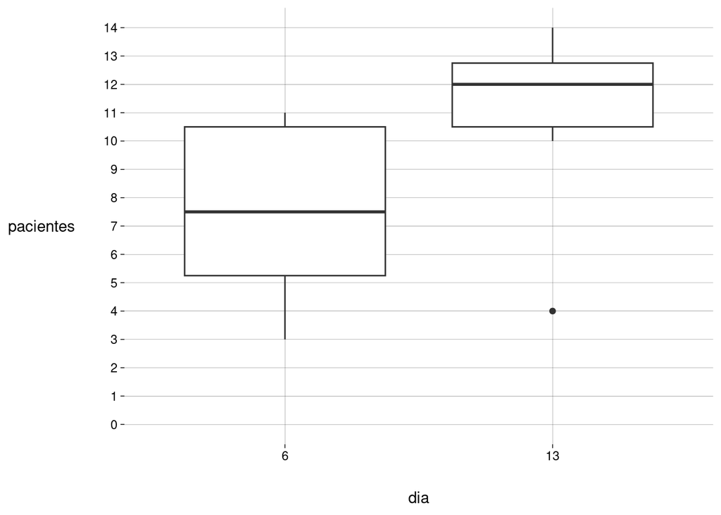

   ```r
   df %>%
     ggplot(aes(factor(dia), pacientes)) +
       geom_boxplot() +
       scale_y_continuous(
         breaks = 0:max(df$pacientes),
         limits = c(0, NA)
       ) +
       labs(x = 'dia')
   ```

   De fato, parece ter havido mais vítimas nas sextas-feiras 13.
2. Faça o seguinte teste de hipóteses, considerando iguais as variâncias dos dois grupos, com $\alpha = 0{,}05$:
   1. $H_0:$ a diferença entre a média de pacientes no dia $6$ e a média de pacientes no dia $13$ é igual a zero.
   2. $H_A:$ a diferença entre a média de pacientes no dia $6$ e a média de pacientes no dia $13$ é menor que zero (i.e., a média no dia $6$ é menor).

   **Resposta**

   Este é um teste com duas amostras não-pareadas.

   ```r
   t.test(
     df %>% filter(dia == 6)  %>% pull(pacientes),
     df %>% filter(dia == 13) %>% pull(pacientes),
     var.equal = TRUE,
     alternative = 'less'
   )
   ```

   ```
    Two Sample t-test

   data:  df %>% filter(dia == 6) %>% pull(pacientes) and df %>% filter(dia == 13) %>% pull(pacientes)
   t = -1,6644, df = 10, p-value = 0,06351
   alternative hypothesis: true difference in means is less than 0
   95 percent confidence interval:
       -Inf 0,29662
   sample estimates:
   mean of x mean of y
     7,50000  10,83333
   ```

   Com $\alpha = 0{,}5$ e o valor p acima, não podemos rejeitar a hipótese de nulidade. A diferença entre as médias não é significativa.
3. Agora, faça o seguinte teste de hipóteses, considerando iguais as variâncias dos dois grupos, com $\alpha = 0{,}05$:
   1. $H_0:$ em cada par de sexta-feira $6$ e sexta-feira $13$ subsequente, a diferença entre as quantidades de pacientes é igual a zero, em média.
   2. $H_A:$ em cada par de sexta-feira $6$ e sexta-feira $13$ subsequente, a diferença entre as quantidades de pacientes é menor que zero, em média (i.e., a quantidade no dia $6$ é menor, em média).

   **Resposta**

   Este é um teste com duas amostras pareadas.

   ```r
   t.test(
     df %>% filter(dia == 6)  %>% pull(pacientes),
     df %>% filter(dia == 13) %>% pull(pacientes),
     var.equal = TRUE,
     alternative = 'less',
     paired = TRUE
   )
   ```

   ```
    Paired t-test

   data:  df %>% filter(dia == 6) %>% pull(pacientes) and df %>% filter(dia == 13) %>% pull(pacientes)
   t = -2,7116, df = 5, p-value = 0,0211
   alternative hypothesis: true mean difference is less than 0
   95 percent confidence interval:
          -Inf -0,8562896
   sample estimates:
   mean difference
         -3,333333
   ```

   Com $\alpha = 0{,}5$ e o valor p acima, rejeitamos a hipótese de nulidade. A diferença média entre as quantidades de pacientes é significativa.
4. Qual dos dois testes você acha mais apropriado usar para responder a pergunta “Sextas-feiras $13$ são mais perigosas?”? Por quê?

   **Resposta**

   O primeiro teste compara todas as sextas-feiras 13 (em conjunto) com todas as sextas-feiras 6 (em conjunto).

   O segundo teste compara cada sexta-feira 13 com cada sexta-feira 6 imediatamente anterior.

   Se você acha que existe ligação entre duas sextas-feiras consecutivas (por exemplo, as duas estão em um mês onde houve mais acidentes), o segundo teste é mais indicado.

   De fato, o seguinte gráfico mostra a correlação entre cada sexta-feira 13 e a sexta-feira imediatamente anterior:

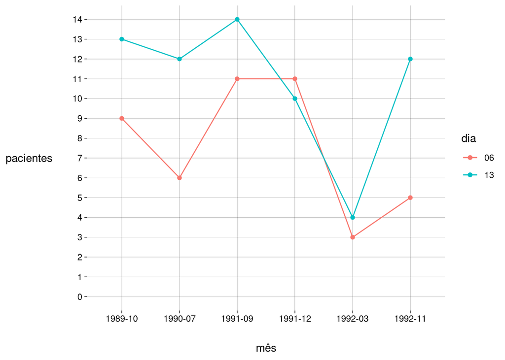

   ```r
   num_mes <- function(x) {

     nomes = c(
       'janeiro', 'fevereiro', 'março', 'abril', 'maio', 'junho',
       'julho', 'agosto', 'setembro', 'outubro', 'novembro', 'dezembro'
     )

     num_meses <- sprintf('%02d', 1:12)
     names(num_meses) <- nomes

     num_meses[x]

   }

   df2 <- df %>%
     mutate(
       mês = paste0(ano, '-', num_mes(mês))
     ) %>%
     arrange(mês)

   ggplot() +
     geom_line(
       data = df2 %>% filter(dia == 6),
       mapping = aes(mês, pacientes, color = '06', group = 6)
     ) +
     geom_point(
       data = df2 %>% filter(dia == 6),
       mapping = aes(mês, pacientes, color = '06', group = 6)
     ) +
     geom_line(
       data = df2 %>% filter(dia == 13),
       mapping = aes(mês, pacientes, color = '13', group = 13),
     ) +
     geom_point(
       data = df2 %>% filter(dia == 13),
       mapping = aes(mês, pacientes, color = '13', group = 13),
     ) +
     scale_y_continuous(breaks = 0:max(df$pacientes), limits = c(0, NA)) +
     labs(color = 'dia')
   ```

   O coeficiente de correlação entre cada sexta-feira 13 e a sexta-feira imediatamente anterior é

   ```r
   cor(
     df %>% filter(dia == 6)  %>% pull(pacientes),
     df %>% filter(dia == 13) %>% pull(pacientes)
   )
   ```

   ```
   [1] 0,625152
   ```

# Vendas

O *dataframe* abaixo mostra a relação entre a quantidade de vendedores em uma loja e a receita das vendas (em R$ $1.000$):

| vendedores | vendas |
| --- | --- |
| 2 | 10 |
| 3 | 11 |
| 7 | 13 |
| 9 | 14 |
| 10 | 18 |
| 10 | 20 |
| 12 | 20 |
| 15 | 22 |
| 16 | 22 |
| 20 | 26 |

1. Faça um *scatter plot*.

   **Resposta**

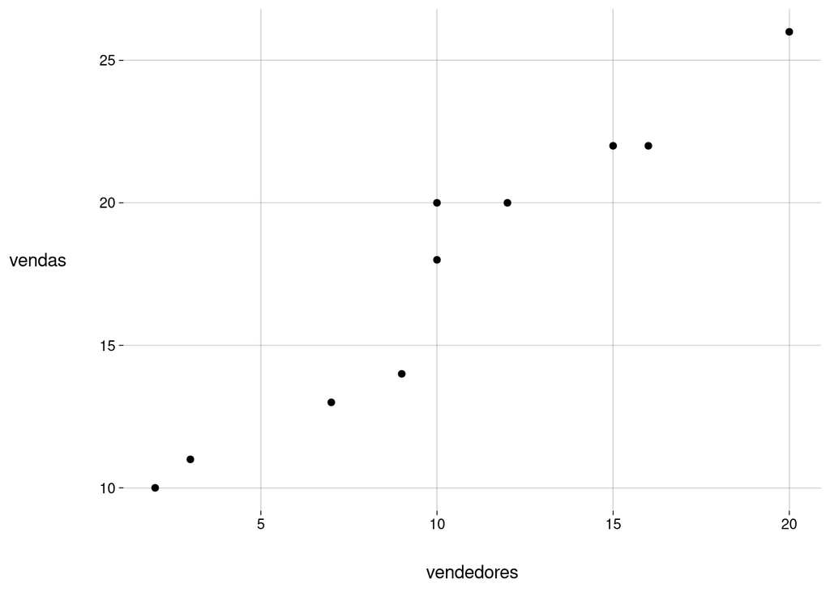

   ```r
   grafico <- df %>%
     ggplot(aes(vendedores, vendas)) +
       geom_point()

   grafico
   ```

2. Qual é a correlação entre estas variáveis?

   **Resposta**

   ```r
   cor(df$vendedores, df$vendas)
   ```

   ```
   [1] 0,9653665
   ```

3. O gerente quer estudar como as vendas variam em função da quantidade de vendedores. Ache a equação da reta de melhor ajuste usando regressão linear.

   **Resposta**

   ```r
   modelo <- lm(vendas ~ vendedores, df)
   summary(modelo)
   ```

   ```
   Call:
   lm(formula = vendas ~ vendedores, data = df)

   Residuals:
       Min      1Q  Median      3Q     Max
   -2,3212 -0,6285  0,1159  0,6236  2,7654

   Coefficients:
               Estimate Std. Error t value   Pr(>|t|)
   (Intercept)  8,10056    1,02080   7,936 0,00004629 ***
   vendedores   0,91341    0,08728  10,466 0,00000604 ***
   ---
   Signif. codes:  0 '***' 0,001 '**' 0,01 '*' 0,05 '.' 0,1 ' ' 1

   Residual standard error: 1,477 on 8 degrees of freedom
   Multiple R-squared:  0,9319, Adjusted R-squared:  0,9234
   F-statistic: 109,5 on 1 and 8 DF,  p-value: 0,000006037
   ```

   ```r
   intercepto <- coef(modelo)[1]
   coef_vendedores <- coef(modelo)[2]
   ```

   A equação é

   $$\widehat{\text{vendas}}
   = 8{,}10 + 0{,}91 \cdot \text{vendedores}$$
   Graficamente:

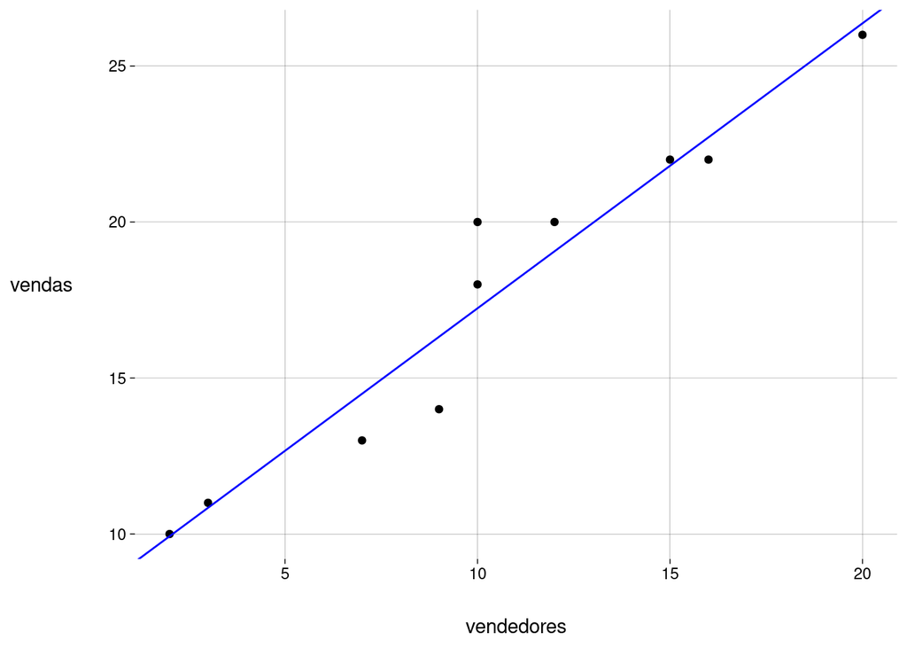

   ```r
   grafico +
     geom_abline(
       slope = coef_vendedores,
       intercept = intercepto,
       color = 'blue'
     )
   ```

4. O que significa o termo constante desta equação?

   **Resposta**

   O termo constante é o chamado intercepto.

   Teoricamente, é a receita das vendas se a quantidade de vendedores fosse zero.

   Como o nome diz, é o valor em que a reta corta o eixo $y$.
5. O que significa o coeficiente da variável nesta equação?

   **Resposta**

   Significa o aumento nas vendas para cada vendedor adicional.
6. Faça um histograma de todos os resíduos. Comente o gráfico.

   **Resposta**

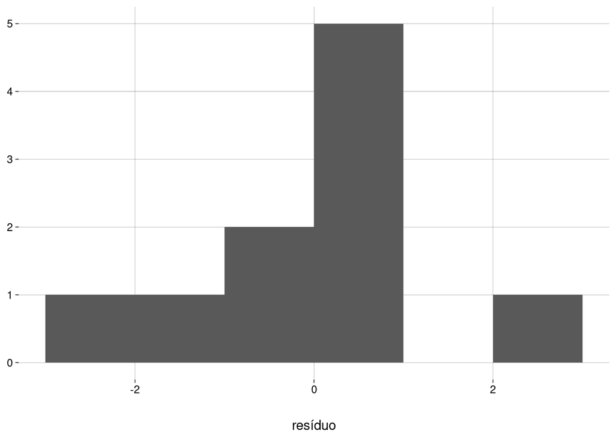

   ```r
   modelo_augment <- augment(modelo)

   modelo_augment %>%
     ggplot(aes(.resid)) +
       geom_histogram(breaks = -3:3) +
       labs(x = 'resíduo', y = NULL)
   ```

   Os resíduos deveriam seguir uma distribuição normal. Com apenas $10$ observações, fica difícil avaliar, mas o teste de Shapiro confirma a normalidade:

   ```r
   shapiro.test(modelo_augment$.resid)
   ```

   ```
    Shapiro-Wilk normality test

   data:  modelo_augment$.resid
   W = 0,96744, p-value = 0,8662
   ```

7. Faça um *scatter plot* de todos os resíduos por valor previsto. Comente o gráfico.

   **Resposta**

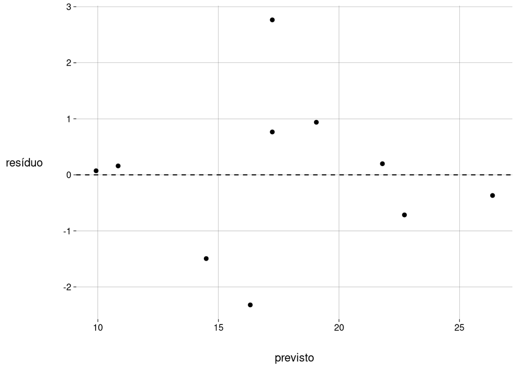

   ```r
   modelo_augment %>%
     ggplot(aes(.fitted, .resid)) +
       geom_point() +
       geom_hline(yintercept = 0, linetype = 'dashed') +
       labs(
         x = 'previsto',
         y = 'resíduo'
       )
   ```

   De novo, a pequena quantidade de observações atrapalha, mas parece não haver padrões na nuvem de pontos.
8. Se houver $18$ vendedores, qual a receita prevista?

   **Resposta**

   ```r
   receita_prevista <- predict(modelo, tibble(vendedores = 18))
   receita_prevista
   ```

   ```
         1
   24,5419
   ```

   **Resposta**

   ```r
   25 - receita_prevista
   ```

   ```
           1
   0,4581006
   ```

## Notas de rodapé

[^1]: O método assintótico foi o que usamos nos cálculos teóricos no curso.